# Free offline HIPPA compliant geocoding in R

Russ

2022-04-19

## Background

This process uses an offline geocoding database hosted on a docker image on the user’s computer. The geocoding database is called Nominatim and is developed by the Open Streets Map Foundation.

## Benefits of this approach

1. It’s free
2. It is done entirely behind our local firewall, so protected health information (PHI) does **not** goes out to the internet
3. It can be called using R, allowing for reproducibility and direct integration with other data analysis processes

## Disadvantages of this approach

1. Relatively involved setup process
2. I’m not sure how accuracy compares to Google or ArcGIS

## Prerequisites

1. Install [R](https://cran.rstudio.com/bin/windows/base/R-4.1.3-win.exe) and [R Studio](https://download1.rstudio.org/desktop/windows/RStudio-2022.02.1-461.exe).  
   This assumes you are running windows, for a link to the install page please see [this](https://www.rstudio.com/products/rstudio/download/#download) site.
2. Install the `tmaptools` package  
   After you’ve installed R and Rstudio, open Rstudio and type the following into the console and press enter:

```
install.packages("tmaptools")
```

You only need to install `tmaptools` once.

## Online Geocoding in R

For example data, we’ll use the Rhode Island state capitol. This is what I put in R:

```r
RI_state_capitol <- "82 Smith St, Providence, RI 02903"
```

Then I’m using the the `geocode_OSM()` function from the `tmaptools` function to geocode

```r
#this loads the library, you have to do this every time you restart R
library(tmaptools)

tmaptools::geocode_OSM(RI_state_capitol)
```

```
## $query
## [1] "82 Smith St, Providence, RI 02903"
##
## $coords
##         x         y
## -71.41496  41.83090
##
## $bbox
##      xmin      ymin      xmax      ymax
## -71.41558  41.83064 -71.41434  41.83115
```

This works, yay! The problem is that the default is to send the address to the online server.  
From the [documentation](https://www.rdocumentation.org/packages/tmaptools/versions/3.1-1/topics/geocode_OSM):

```
geocode_OSM(
  q,
  projection = NULL,
  return.first.only = TRUE,
  keep.unfound = FALSE,
  details = FALSE,
  as.data.frame = NA,
  as.sf = FALSE,
  geometry = c("point", "bbox"),
  server = "https://nominatim.openstreetmap.org"
)
```

But there’s also the option to send the addresses to a local Nominatim server:

```
server   OpenStreetMap Nominatim server name. Could also be a local OSM Nominatim server
```

## Mediagis/Nominatim Docker image

Open Street Maps allows people to download and setup an offline database of addresses for geocoding. However, the nominatim [documentation](https://nominatim.org/release-docs/develop/admin/Installation/) doesn’t have install instructions for windows, so I decided the easiest thing to do would be to run nominatim as a docker container. Here’s how I did that:

1. I installed Docker following these [instructions](https://docs.docker.com/desktop/windows/install/).
2. Then I followed these [instructions](https://github.com/mediagis/nominatim-docker/tree/master/4.0) to setup a nominatim docker container and entered the following in the Windows command line prompt:

```
docker run -it --rm -e PBF_URL=https://download.geofabrik.de/north-america/us/rhode-island-latest.osm.pbf -e REPLICATION_URL=https://download.geofabrik.de/north-america/us-northeast-updates/ -p 8080:8080 --name nominatim mediagis/nominatim:4.0
```

I only want to geocode addresses in Rhode Island, so that’s why I used the urls that I did. A bunch of stuff flashed across the cmd, and then I got this as the last line:

```
database system is ready to accept connections
```

## Offline Geocoding R

I closed the command prompt and went back to R. In R I changed the `server=` argument in `geocode_OSM()` to `server = "http://localhost:8080/"` which corresponds to the local port I chose for the nominatim docker container. I disconnected from the internet and tested the offline local Nominatim server with several addresses:

```r
# State Capital
tmaptools::geocode_OSM(RI_state_capitol, server = "http://localhost:8080/")
```

```
## $query
## [1] "82 Smith St, Providence, RI 02903"
##
## $coords
##         x         y
## -71.41496  41.83090
##
## $bbox
##      xmin      ymin      xmax      ymax
## -71.41558  41.83064 -71.41434  41.83115
```

```r
#Newport Tennis Museum
tmaptools::geocode_OSM("194 Bellevue Ave, Newport, RI 02840", server = "http://localhost:8080/")
```

```
## $query
## [1] "194 Bellevue Ave, Newport, RI 02840"
##
## $coords
##         x         y
## -71.30837  41.48278
##
## $bbox
##      xmin      ymin      xmax      ymax
## -71.30842  41.48273 -71.30832  41.48283
```

```r
#Massachusetts State Capital
tmaptools::geocode_OSM("24 Beacon St, Boston, MA 02133", server = "http://localhost:8080/")
```

```
## No results found for "24 Beacon St, Boston, MA 02133".
```

It works! I can geocode offline for addresses in Rhode Island. It doesn’t work for Massachusetts addresses, but that was by design.

## Batch Geocoding

Multiple addresses can also be geocoded all at once

```r
lots_of_addresses <- c(RI_state_capitol,"194 Bellevue Ave, Newport, RI 02840","24 Beacon St, Boston, MA 02133")
lots_of_points <- tmaptools::geocode_OSM(lots_of_addresses, server = "http://localhost:8080/")
```

```
## No results found for "24 Beacon St, Boston, MA 02133".
```

```r
DT::datatable(lots_of_points, options = list(pageLength = 3, scrollX = TRUE))
```

|  | query | lat | lon | lat_min | lat_max | lon_min | lon_max |
| --- | --- | --- | --- | --- | --- | --- | --- |
| 1 | 82 Smith St, Providence, RI 02903 | 41.83089555 | -71.4149586644758 | 41.8306394 | 41.8311538 | -71.4155822 | -71.4143351 |
| 2 | 194 Bellevue Ave, Newport, RI 02840 | 41.4827777 | -71.3083749 | 41.4827277 | 41.4828277 | -71.3084249 | -71.3083249 |

This could also come from a spreadsheet with a column of addresses

# Maps

Then we can use all the points to make maps or do whatever else we want

```r
# Here's a library we might need
# If this library isn't already installed you need to run install.packages("tmap)
library(tmap)
tmap_mode("view")
```

```
## tmap mode set to interactive viewing
```

```r
#here's a map of Rhode Island
library(sf)
# the shapefile comes from this website: https://www.rigis.org/datasets/edc::state-boundary-1997/about

ri <- st_read("https://services2.arcgis.com/S8zZg9pg23JUEexQ/arcgis/rest/services/State_Boundary_1997/FeatureServer/0/query?outFields=*&where=1%3D1&f=geojson")
tm_shape(ri)+ tm_fill(col = "green", alpha = 0.2)+tm_layout(frame = FALSE)
```

[interactive chart not shown]

```r
#Now let's put the points on the map
random_points_sf <- st_as_sf(lots_of_points, coords = c("lon","lat"), crs= st_crs(ri))

#here's dynamic map
tm_shape(ri)+
  tm_fill(col = "green", alpha = 0.2)+
  tm_shape(random_points_sf)+
  tm_dots(col = "red")+
  tm_layout(frame = FALSE,
            outer.margins = c(0.1,0.1,0.1,0.1),
            title = "My favorite places in Rhode Island")
```

[interactive chart not shown]

```r
#and a static map
tmap_mode("plot")
```

```
## tmap mode set to plotting
```

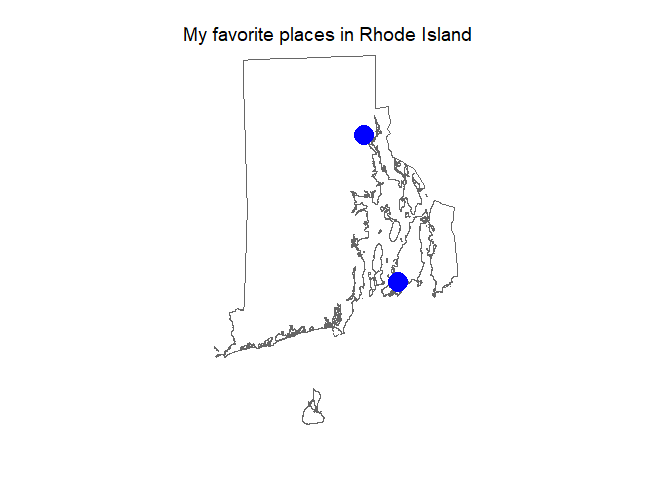

```r
tm_shape(ri)+
  tm_borders()+
  tm_shape(random_points_sf)+
  tm_dots(col = "blue", size = 2)+
  tm_layout(frame = FALSE,
            inner.margins = c(0.1,0.1,0.1,0.1),
            title = "My favorite places in Rhode Island",
            title.position = c(0,0.95))
```

# FAQ and Troubleshooting

**Q: When I try to run the Docker container I get an error about self-signed certificates**

*A:This is likely an issue with how our firewall is setup. When I tried this on a work computer at a previous employer I occasionally got this error, but I never got it on my personal computer*

**Q: What is Docker?**

*A: It is a way to distribute software and manage dependencies in a way that isn’t specific to any operating system. We’re using it here because the nominatim offline database is optimized to be setup on a computer running linux. Here’s a link to their description page: https://docs.docker.com/get-started/overview/*

**Q: Are there security or privacy risks to this approach**

*A: All software, including enterprise software from large companies such as Microsoft, may potentially have security vulnerabilities. [Docker](https://www.docker.com/) and [Open Street Maps/nominatim](https://welcome.openstreetmap.org/) are well established softwares, used and trusted by millions of users and [organizations](https://welcome.openstreetmap.org/about-osm-community/consumers/).*

*All the data stays behind our local firewall and is geocoded offline.*